# Make Your Own AFL Graph

Robert Nguyen

2018-05-04

> “The greatest value of a picture is when it forces us to notice what we never expected to see.” - J. W. Tukey (1977)

To learn a new skill I think there needs to be 2 main drivers

- An interest in a topic
- easy to get to tangible wins to encourage deeper understanding

Hopefully you have stumbled across this blog because you have an interest in footy and because you want to start analysing the game yourself. So lets gets started.

The graph you are going to be able to create by the end of this post, is a cummulative line chart showing how quickly a player racks up a certain stat. For an example of a final product you can have a look at a [graph](https://twitter.com/anoafl/status/992235792121516032) produced by Matt Cowgill.

To get started using R you can download R from [here](https://www.r-project.org) and a nice Rstudio from [here](https://www.rstudio.com/products/rstudio/download/).

Once you have those both installed, lets get cracking.

```r
install.packages("tidyverse")
install.packages("devtools")
devtools::install_github("jimmyday12/fitzRoy")
library(fitzRoy)
library(tidyverse)
```

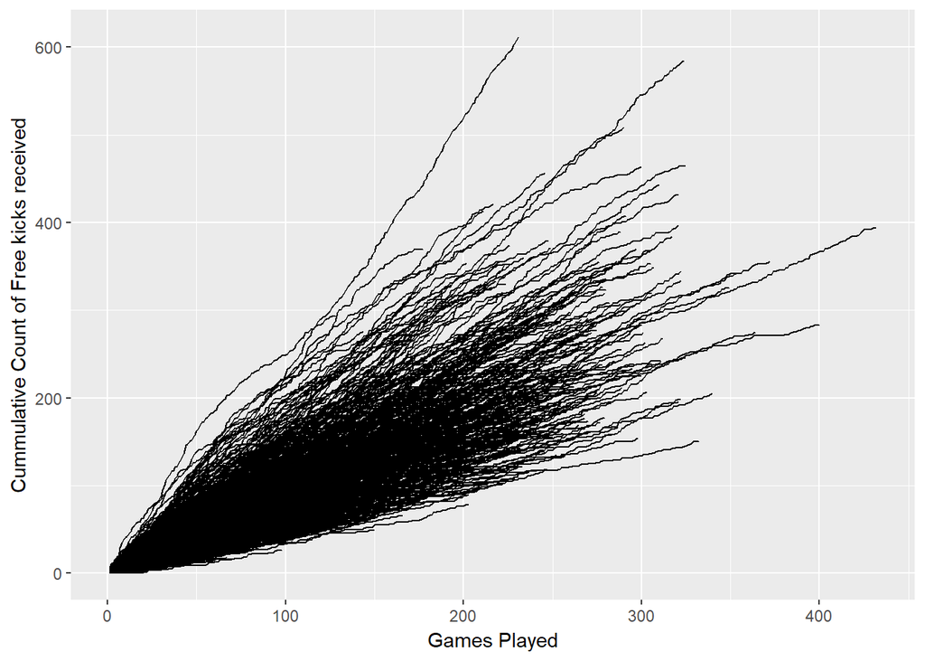

```r
df<-fitzRoy::afldata
df%>%filter(Season>1990)%>%
  group_by(ID) %>%
  mutate(games_played=row_number())%>%
  mutate(cummulativefrees=cumsum(Frees.For))%>%

ggplot(aes(x=games_played, y=cummulativefrees, group = ID)) + geom_line() +xlab("Games Played") +ylab("Cummulative Count of Free kicks received")
```

Hopefully you are able to run the script above and get the same graph. If not #makemeauseR and tweet [at me](https://twitter.com/anoafl) and I will lend a hand. Alternively there are great open slack groups like the [R4DS](https://medium.com/@kierisi/r4ds-the-next-iteration-d51e0a1b0b82) where members are some of the most helpful going around!

So now you have hopefully the quick win out the way and you are now a bit more keen on diving in and seeing how this all works.

# Why use ggplot2

- The writing of the code helps you think about how your data drives the visualisation journey
- easy to use and make changes if you want to see different variables, timeframes etc

# Before you plot checklist

- data is tidy
- each variable is a column
- each observation is a row

# Another example a little explanation

Get the data – [fitzRoy](https://jimmyday12.github.io/fitzRoy/index.html) hopefully makes this an easier job because the data is already stored in a [tidy format](https://www.jstatsoft.org/article/view/v059i10/v59i10.pdf)

But its not just enough to have data, after all whats the point? You want to do some analyse and visualise data because you have a question in mind, you are driven to look into something that you find interesting.

So with that in mind, lets see if there is a relationship between `Contested.Marks` and `Weight`.

```r
# install.packages("devtools")
devtools::install_github("jimmyday12/fitzRoy")
library(fitzRoy)
library(tidyverse)
df<-fitzRoy::afldata
```

Now that you have your dataframe `df` you can see that it collection of variables (columns) and observations of those variables (rows) `df` looking at some of these variables in `df`

- `Weight`
- `Contested.Marks`

# Bit more ploting explanation

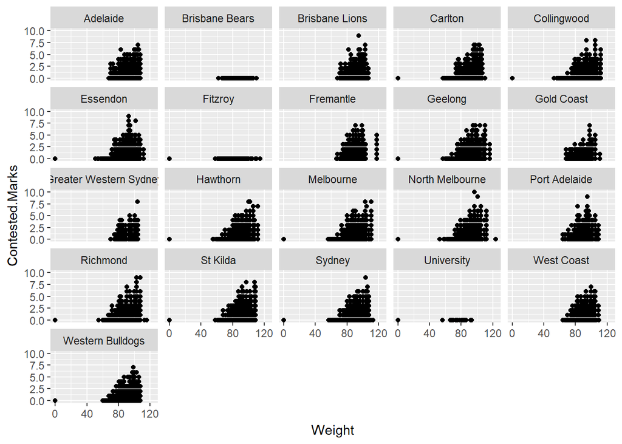

```r
df%>%
ggplot(aes(x=Weight, y=Contested.Marks)) +
  geom_point() + facet_wrap(~Playing.for)
```

Let me explain some of the commands going on here.

`df` is what we called our dataframe before, this is followed by the ‘pipe’ operator `%>%`. In simple terms it takes the output of one `df` and inserts it into the next `ggplot` In short this “chaining” allows you to pass a result onto the next function. For the above example we first create a dataframe called `df` (how creative) the next line we take this data and this dataframe `df` becomes the data we will base our plot off.

# `aes`

`aes`– Aesthetic mappings describe how variables in the data are mapped to visual properties (aesthetics) of geoms. Aesthetics are things such as xy and colours `x=Weight, y=Contested.Marks` `colour=Playing.For`

# `geom`

Geoms are the geometric objects displayed in the plot. Here `geom_` controls the type of [plot](http://ggplot2.tidyverse.org/reference/) you want. For example `geom_point` will give you a scatterplot, `geom_line` a line graph

# `facet`

Facet is a more general case of common [conditioned or trellis plots](https://www.stat.auckland.ac.nz/~ihaka/787/lectures-trellis.pdf). Faceting creates small multiples of different subsets of a dataset. These plots come in handy when you want to compare if patterns are the same or different across conditions `facets`

# Putting it all together

- Question - I want to visualise the MAE of the [squiggle](http://squiggle.com.au/) tipsters.

Thankfully, fitzRoy has easy to use functions to get the squiggle data!

```r
library(fitzRoy)
tips <- get_squiggle_data("tips")
```

```
## Getting data from https://api.squiggle.com.au/?q=tips
```

```r
head(tips)
```

```
##   correct   err round sourceid hteamid       hteam hconfidence margin
## 1       1 42.00     1        1       3     Carlton        50.0   1.00
## 2       1    NA     1        3       3     Carlton        42.0     NA
## 3       0 48.39     1        4       3     Carlton        56.7   5.39
## 4       1  3.69     1        4       4 Collingwood        37.3  10.31
## 5       1  3.00     1        1       4 Collingwood        38.0  17.00
## 6       1 53.00     1        1       1    Adelaide        50.0   3.00
##            source ateamid gameid              tip                  ateam
## 1        Squiggle      14      1         Richmond               Richmond
## 2  Figuring Footy      14      1         Richmond               Richmond
## 3 Matter of Stats      14      1          Carlton               Richmond
## 4 Matter of Stats      18      2 Western Bulldogs       Western Bulldogs
## 5        Squiggle      18      2 Western Bulldogs       Western Bulldogs
## 6        Squiggle       9      8         Adelaide Greater Western Sydney
##   tipteamid         venue    bits             updated                date
## 1        14        M.C.G.  0.0000 2017-07-11 13:59:46 2017-03-23 19:20:00
## 2        14        M.C.G.  0.2141 2017-04-10 12:18:02 2017-03-23 19:20:00
## 3         3        M.C.G. -0.2076 2017-07-11 13:59:46 2017-03-23 19:20:00
## 4        18        M.C.G.  0.3265 2017-07-11 13:59:46 2017-03-24 19:50:00
## 5        18        M.C.G.  0.3103 2017-07-11 13:59:46 2017-03-24 19:50:00
## 6         1 Adelaide Oval  0.0000 2017-07-11 13:59:46 2017-03-26 15:20:00
##   year confidence
## 1 2017       50.0
## 2 2017       58.0
## 3 2017       56.7
## 4 2017       62.7
## 5 2017       62.0
## 6 2017       50.0
```

## Getting data in the right format

What do I actually want to visualise here?

I would like to see the data for this year 2018 `filter(year>2017)` that shows me for a given round and tipster `group_by(round, source)` of the squiggle tipsters by round and tipster their average MAE for that round by said tipster `summarise(MAE_by_round=mean(err))`

```r
 tips%>%
  filter(year>2017)%>%
   group_by(round, source)%>%
   summarise(MAE_by_round=mean(err))
```

```
## # A tibble: 189 x 3
## # Groups:   round [?]
##    round source                MAE_by_round
##    <int> <chr>                        <dbl>
##  1     1 Aggregate                     21.2
##  2     1 Footy Maths Institute         26
##  3     1 Graft                         20.1
##  4     1 HPN                           31.7
##  5     1 Live Ladders                  20.8
##  6     1 Matter of Stats               24.4
##  7     1 PlusSixOne                    19.7
##  8     1 Punters                       NA
##  9     1 Squiggle                      22
## 10     1 Stattraction                  21.8
## # ... with 179 more rows
```

Now that we have our data in the right format for plotting lets you know get plotting!

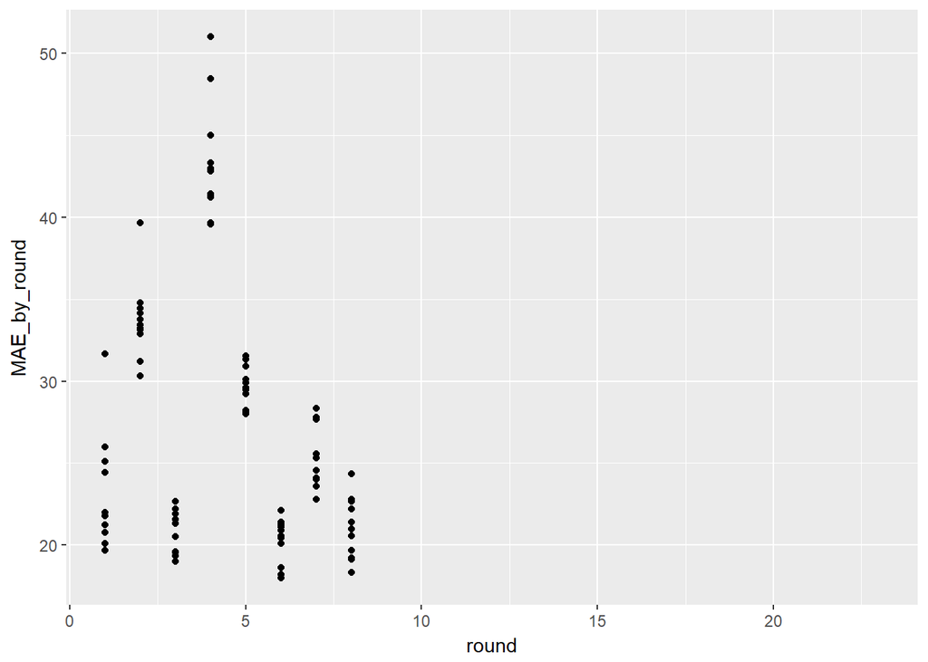

```r
tips%>%
  filter(year>2017)%>%
   group_by(round, source)%>%
   summarise(MAE_by_round=mean(err))%>%
  ggplot(aes(x=round, y=MAE_by_round))+
  geom_point()
```

So what can we see here? We can see the average MAE by tipster by round for 2018. The problem is we can’t identify which tipster is who. So how can we do that? Just add colour.

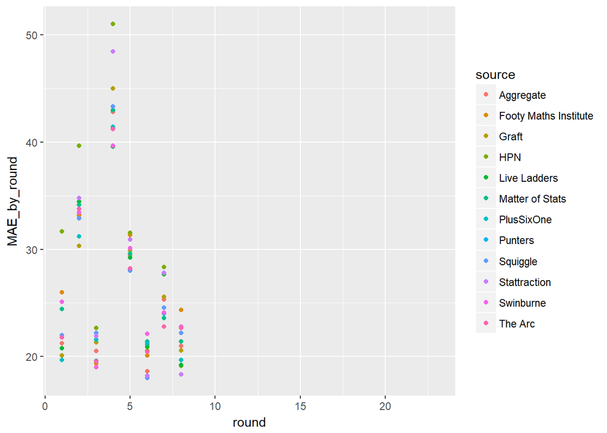

```r
tips%>%
  filter(year>2017)%>%
   group_by(round, source)%>%
   summarise(MAE_by_round=mean(err))%>%
  ggplot(aes(x=round, y=MAE_by_round))+
  geom_point(aes(colour=source))
```

Ok now that we have added some colour things are still hard to see, so what if we joined each point for the respective tipster?

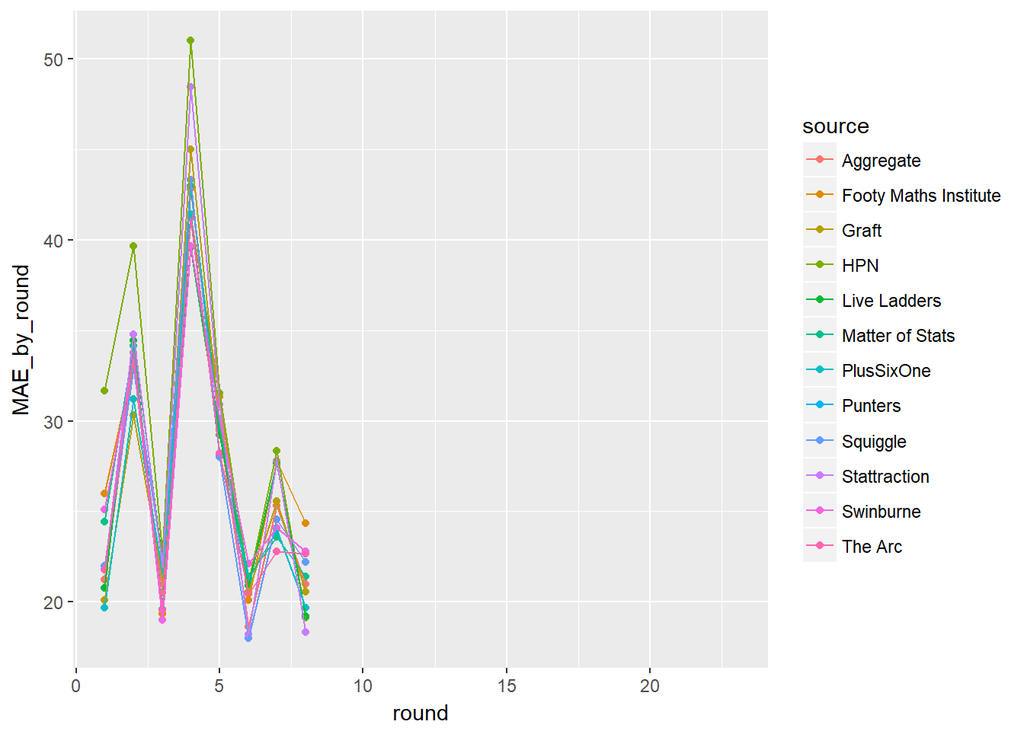

```r
tips%>%
  filter(year>2017)%>%
   group_by(round, source)%>%
   summarise(MAE_by_round=mean(err))%>%
  ggplot(aes(x=round, y=MAE_by_round))+
  geom_point(aes(colour=source)) +
  geom_line(aes(group=source, colour=source))
```

Ok so now things are a bit clearer but still not as clear as we would like. Its hard to get a feel for each individual tipster because all the points are fairly close which makes our lines close together so disentanglement becomes difficult. This is where faceting or small multiples comes in handy.

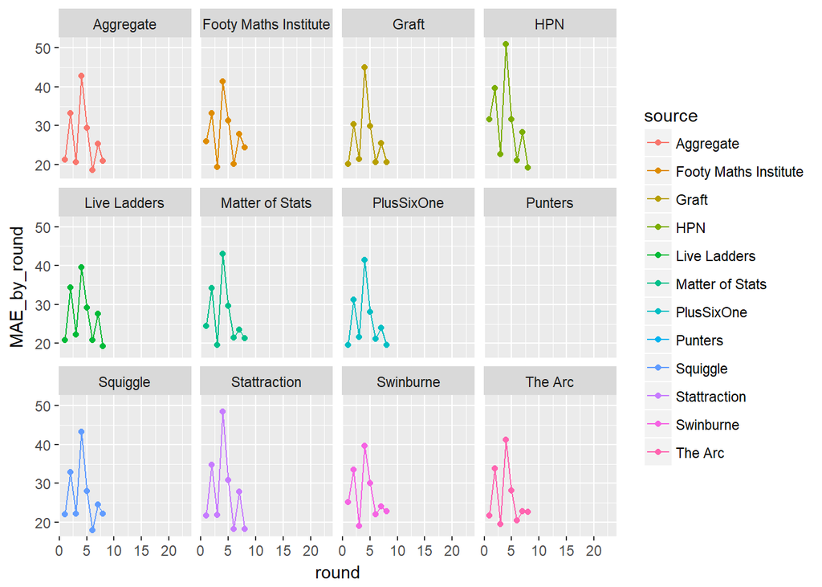

```r
tips%>%
  filter(year>2017)%>%
   group_by(round, source)%>%
   summarise(MAE_by_round=mean(err))%>%
  ggplot(aes(x=round, y=MAE_by_round))+
  geom_point(aes(colour=source)) +
  geom_line(aes(group=source, colour=source)) +facet_wrap(~source)
```

There you go how cool is that.